# 项目背景：

从去年开始准备转行，一直在学习Python及其数据分析库、SQL、机器学习与数学基础，目前对整个数据分析项目基本技能的理解及使用已经比较熟练，因为面临找工作的问题，从kaggle等平台做一些实战项目，进一步练习熟悉numpy、pandas、matplotlib、seaborn、特征工程、回归预测建模及模型评估等。

# 项目分析目的及内容：

近几年共享单车越来越火，通过kaggle提供的数据，分析每天的时段、温度、湿度、风速、季节、天气、假期等因素对单车使用量的影响，建模预测在不同时间共享单车的使用总量。 Kaggle所提供的数据描述： （1） 日期时间：年/月/日/时间，例：2011/1/1 0:00 （2） 季节：1=春，2=夏，3=秋天，4=冬天 （3） 假日：是否是节假日（0=否，1=是） （4） 工作日：是否是工作日（0=否，1=是） （5） 天气：1=晴天、多云等（良好），2=阴天薄雾等（普通），3=小雪、小雨等（稍 差），4=大雨、冰雹等（极差） （6） 实际温度（℃） （7） 感觉温度（℃） （8） 湿度 （9） 风速 （10）未注册用户租借数量 （11）注册用户租借数量 （12）总租借数量 这里只预测使用总量，忽略未注册与注册用户使用量。

# 一、数据导入与初探

```python
import pandas as pd
import numpy as np
from IPython.display import display

train_data=pd.read_csv(r'D:\AI\DataScience\gongxiangdanche\train.csv')
test_data=pd.read_csv(r'D:\AI\DataScience\gongxiangdanche\test.csv')
train_data.info()
train_data.isnull().sum()
display(train_data.head(n=2))
```

```
<class 'pandas.core.frame.DataFrame'>
RangeIndex: 10886 entries, 0 to 10885
Data columns (total 12 columns):
datetime      10886 non-null object
season        10886 non-null int64
holiday       10886 non-null int64
workingday    10886 non-null int64
weather       10886 non-null int64
temp          10886 non-null float64
atemp         10886 non-null float64
humidity      10886 non-null int64
windspeed     10886 non-null float64
casual        10886 non-null int64
registered    10886 non-null int64
count         10886 non-null int64
dtypes: float64(3), int64(8), object(1)
memory usage: 1020.6+ KB
```

|  | datetime | season | holiday | workingday | weather | temp | atemp | humidity | windspeed | casual | registered | count |
| --- | --- | --- | --- | --- | --- | --- | --- | --- | --- | --- | --- | --- |
| 0 | 2011-01-01 00:00:00 | 1 | 0 | 0 | 1 | 9.84 | 14.395 | 81 | 0.0 | 3 | 13 | 16 |
| 1 | 2011-01-01 01:00:00 | 1 | 0 | 0 | 1 | 9.02 | 13.635 | 80 | 0.0 | 8 | 32 | 40 |

数据非常整齐，没有缺失值。

```python
train_data.describe()
```

|  | season | holiday | workingday | weather | temp | atemp | humidity | windspeed | casual | registered | count |
| --- | --- | --- | --- | --- | --- | --- | --- | --- | --- | --- | --- |
| count | 10886.000000 | 10886.000000 | 10886.000000 | 10886.000000 | 10886.00000 | 10886.000000 | 10886.000000 | 10886.000000 | 10886.000000 | 10886.000000 | 10886.000000 |
| mean | 2.506614 | 0.028569 | 0.680875 | 1.418427 | 20.23086 | 23.655084 | 61.886460 | 12.799395 | 36.021955 | 155.552177 | 191.574132 |
| std | 1.116174 | 0.166599 | 0.466159 | 0.633839 | 7.79159 | 8.474601 | 19.245033 | 8.164537 | 49.960477 | 151.039033 | 181.144454 |
| min | 1.000000 | 0.000000 | 0.000000 | 1.000000 | 0.82000 | 0.760000 | 0.000000 | 0.000000 | 0.000000 | 0.000000 | 1.000000 |
| 25% | 2.000000 | 0.000000 | 0.000000 | 1.000000 | 13.94000 | 16.665000 | 47.000000 | 7.001500 | 4.000000 | 36.000000 | 42.000000 |
| 50% | 3.000000 | 0.000000 | 1.000000 | 1.000000 | 20.50000 | 24.240000 | 62.000000 | 12.998000 | 17.000000 | 118.000000 | 145.000000 |
| 75% | 4.000000 | 0.000000 | 1.000000 | 2.000000 | 26.24000 | 31.060000 | 77.000000 | 16.997900 | 49.000000 | 222.000000 | 284.000000 |
| max | 4.000000 | 1.000000 | 1.000000 | 4.000000 | 41.00000 | 45.455000 | 100.000000 | 56.996900 | 367.000000 | 886.000000 | 977.000000 |

平均值大于中位数，数据分布存在一定程度的右偏，最大值与最小值明显区别于平均值，是否为异常值有待进一步分析。

# 二、数据预处理

1、合并训练集与测试集，统一预处理

```python
data=train_data.append(test_data)
data.shape
```

```
(17379, 12)
```

2、拆分时间，变为年、月、日、时

```python
data['year']=data.datetime.apply(lambda x: x.split()[0].split('-')[0])
data['year']=data['year'].apply(lambda x: int(x))
data['month']=data.datetime.apply(lambda x: x.split()[0].split('-')[1])
data['month']=data['month'].apply(lambda x: int(x))
data['day']=data.datetime.apply(lambda x: x.split()[0].split('-')[2])
data['day']=data['day'].apply(lambda x: int(x))
data['hour']=data.datetime.apply(lambda x: x.split()[1].split(':')[0])
data['hour']=data['hour'].apply(lambda x: int(x))
data['date']=data.datetime.apply(lambda x: x.split()[0])
data['weekday']=pd.to_datetime(data['date']).dt.weekday_name
data['weekday']=data['weekday'].map({'Monday':1,'Tuesday':2,'Wednesday':3,
                                         'Thursday':4,'Friday':5,'Saturday':6,'Sunday':7})

#删除无用的列
data=data.drop('datetime',axis=1)

cols=['year','month','day','weekday','hour','season','holiday','workingday','weather','temp','atemp',
        'humidity','windspeed','casual','registered','count']
data=data.loc[:,cols]

display(data.head(n = 2))
```

|  | year | month | day | weekday | hour | season | holiday | workingday | weather | temp | atemp | humidity | windspeed | casual | registered | count |
| --- | --- | --- | --- | --- | --- | --- | --- | --- | --- | --- | --- | --- | --- | --- | --- | --- |
| 0 | 2011 | 1 | 1 | 6 | 0 | 1 | 0 | 0 | 1 | 9.84 | 14.395 | 81 | 0.0 | 3.0 | 13.0 | 16.0 |
| 1 | 2011 | 1 | 1 | 6 | 1 | 1 | 0 | 0 | 1 | 9.02 | 13.635 | 80 | 0.0 | 8.0 | 32.0 | 40.0 |

3、分离训练集与测试集

```python
train=data.iloc[:10886]
test=data.iloc[10886:]
```

# 三、数据可视化分析

```python
import matplotlib.pyplot as plt
import seaborn as sns
```

1、不同时间特征对单车使用量的影响

```
Text(0.5,1,'The influence of hour')
```

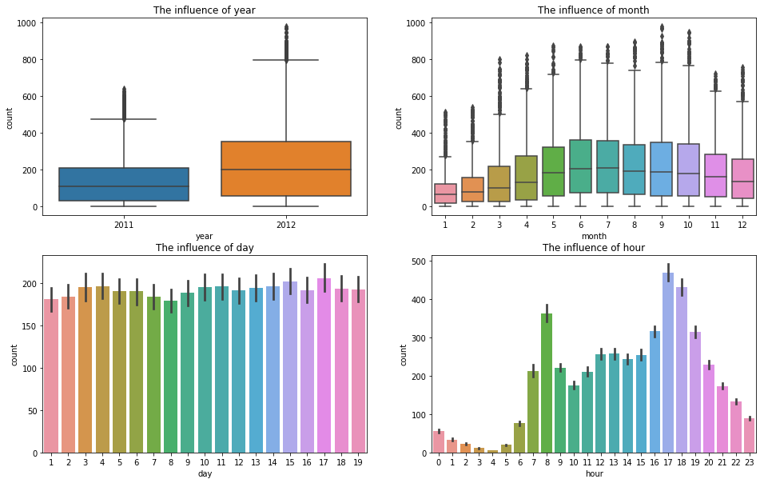

```python
fig, axes=plt.subplots(2,2,figsize=(16, 10))
ax1=plt.subplot(2,2,1)
sns.boxplot(train['year'],train['count'],ax=ax1)
plt.title("The influence of year")

ax2=plt.subplot(2,2,2)
sns.boxplot(train['month'],train['count'],ax=ax2)
plt.title("The influence of month")

ax3=plt.subplot(2,2,3)
sns.barplot(train['day'],train['count'],ax=ax3)
plt.title("The influence of day")

ax4=plt.subplot(2,2,4)
sns.barplot(train['hour'],train['count'],ax=ax4)
plt.title("The influence of hour")
```

可以看出，2012年的使用量相比2011年大幅增长，应该和市场推广密不可分；年中几个月使用量偏高，年底使用量有所下滑；日期天对使用量有一点的周期性规律，可能和双休日有关，有待进一步分析；一天内的不同时段使用量差异最明显，上下班的早晚高峰使用量最大。

2、节假日对单车使用量的影响

```
Text(0.5,1,'The influence of holiday')
```

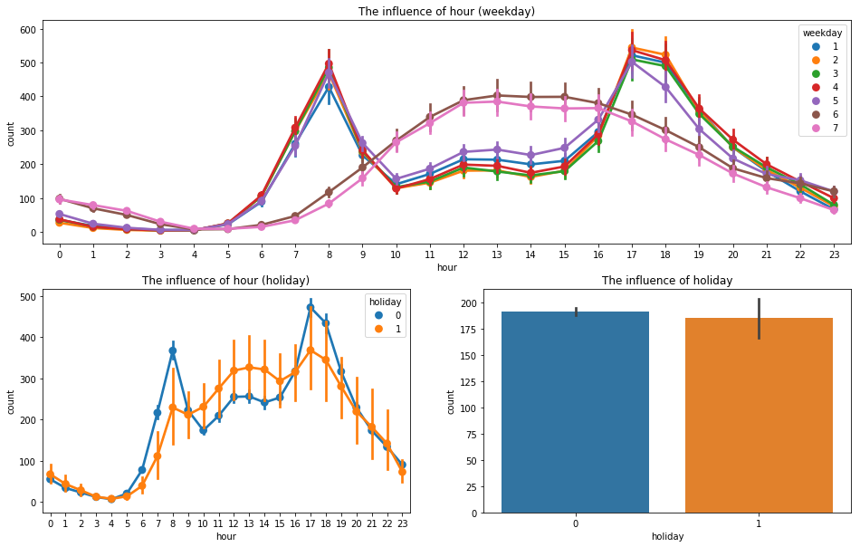

```python
fig, axes=plt.subplots(2,1,figsize=(16, 10))

ax1=plt.subplot(2,1,1)
sns.pointplot(train['hour'],train['count'],hue=train['weekday'],ax=ax1)
ax1.set_title("The influence of hour (weekday)")

ax2=plt.subplot(2,2,3)
sns.pointplot(train['hour'],train['count'],hue=train['holiday'],ax=ax2)
ax2.set_title("The influence of hour (holiday)")

ax3=plt.subplot(2,2,4)
sns.barplot(train['holiday'],train['count'],ax=ax3)
ax3.set_title("The influence of holiday")
```

可见周末或节假日用车与工作日明显不同，工作日集中在早晚上下班高峰期，周末或节假日则集中于正午前后的时段。工作日单车使用量略高,相差不大。

3、季节对单车使用量的影响

```
Text(0.5,1,'The influence of season')
```

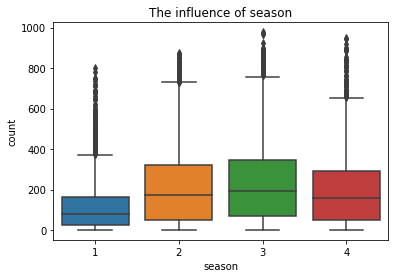

```python
sns.boxplot(train['season'],train['count'])
plt.title("The influence of season")
```

春季开始的几个季度使用量持续升高，秋季使用量最高，冬季明显下降。说明一方面因为持续市场推广及接受度带来使用量的持续升高，另一方面受气候影响较大。

4、天气对使用量的影响

```
Text(0.5,1,'the influence of weather')
```

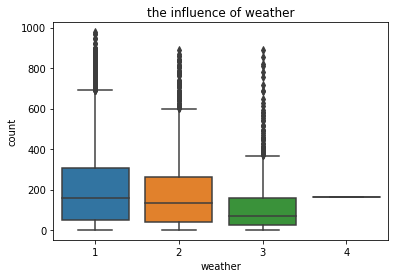

```python
sns.boxplot(train['weather'],train['count'])
plt.title('the influence of weather')
```

5、温湿度等气候因素的影响

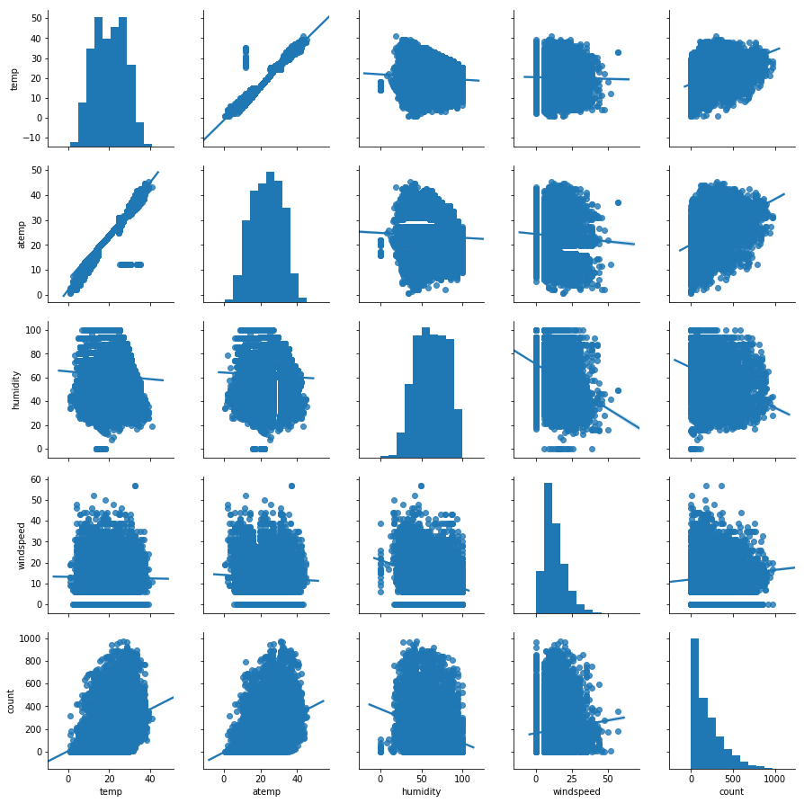

```python
cols=['temp', 'atemp', 'humidity', 'windspeed', 'count']
sns.pairplot(train[cols],kind="reg")
```

可以看出实际温度与感觉温度呈明显线性关系，但也有部分异常数据，应该和风速及湿度有关，后期建模可删除感觉温度。

```
Text(0.5,1,'The influence of windspeed')
```

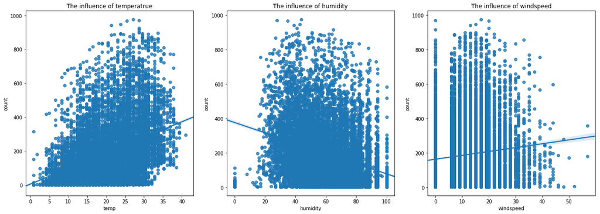

```python
fig,axes=plt.subplots(1,3,figsize=(21,7))

ax1=plt.subplot(1,3,1)
sns.regplot(train['temp'],train['count'],ax=ax1)
ax1.set_title('The influence of temperatrue')

ax2=plt.subplot(1,3,2)
sns.regplot(train['humidity'],train['count'],ax=ax2)
ax2.set_title('The influence of humidity')

ax3=plt.subplot(1,3,3)
sns.regplot(train['windspeed'],train['count'],ax=ax3)
ax3.set_title('The influence of windspeed')
```

三个因素对使用量没有明显线性关系，但温度、风速与使用量呈正相关，湿度与使用量呈负相关，相关性不是特别明显。

6、查看各因素对使用量影响的相关性大小

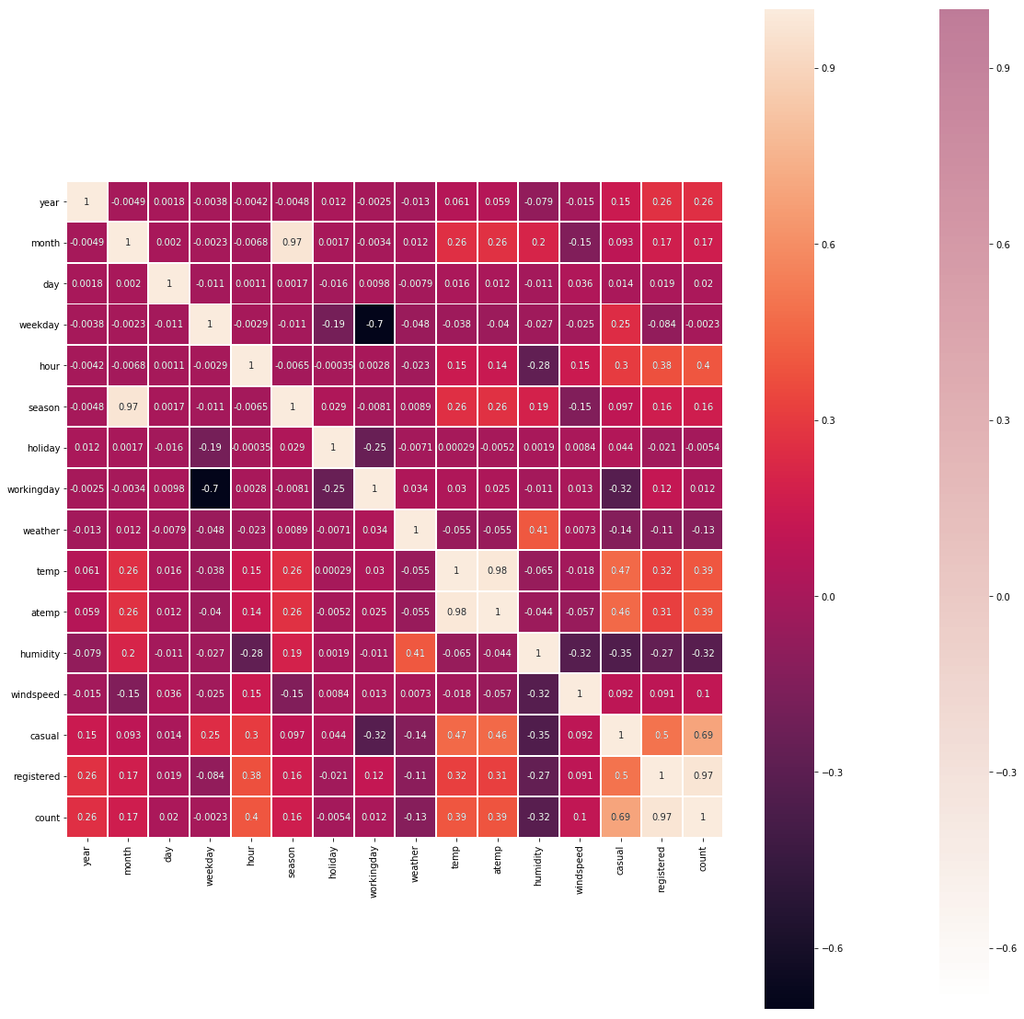

```python
f,ax=plt.subplots(figsize=(20,20))
cmap=sns.cubehelix_palette(light=1,as_cmap=True)
correlation=train.corr()
sns.heatmap(correlation,annot=True,center=1,cmap=cmap,linewidths=1,ax=ax)
sns.heatmap(correlation,vmax=1,square=True,annot=True,linewidths=1)
```

从上面的热力图可以看到各个特征与使用量的相关系数大小，温度、湿度和时段相关性较大，其中实际温度与感觉温度可选一个作为特征；年、月、季节、天气也有一定影响；天、工作日、假期、周末等对使用量影响很小。

# 四、数据清洗

1、删除冗余特征并进行one-hot转换

```python
display(data.head(n=2))

data=data.drop(['day','weekday','atemp','casual','registered'],axis=1)
display(data.head(n=2))

column_trans=['year','month','hour','weather','season']
data=pd.get_dummies(data, columns=column_trans)

display(data.head(n=2))
```

|  | year | month | day | weekday | hour | season | holiday | workingday | weather | temp | atemp | humidity | windspeed | casual | registered | count |
| --- | --- | --- | --- | --- | --- | --- | --- | --- | --- | --- | --- | --- | --- | --- | --- | --- |
| 0 | 2011 | 1 | 1 | 6 | 0 | 1 | 0 | 0 | 1 | 9.84 | 14.395 | 81 | 0.0 | 3.0 | 13.0 | 16.0 |
| 1 | 2011 | 1 | 1 | 6 | 1 | 1 | 0 | 0 | 1 | 9.02 | 13.635 | 80 | 0.0 | 8.0 | 32.0 | 40.0 |

|  | year | month | hour | season | holiday | workingday | weather | temp | humidity | windspeed | count |
| --- | --- | --- | --- | --- | --- | --- | --- | --- | --- | --- | --- |
| 0 | 2011 | 1 | 0 | 1 | 0 | 0 | 1 | 9.84 | 81 | 0.0 | 16.0 |
| 1 | 2011 | 1 | 1 | 1 | 0 | 0 | 1 | 9.02 | 80 | 0.0 | 40.0 |

|  | holiday | workingday | temp | humidity | windspeed | count | year_2011 | year_2012 | month_1 | month_2 | ... | hour_22 | hour_23 | weather_1 | weather_2 | weather_3 | weather_4 | season_1 | season_2 | season_3 | season_4 |
| --- | --- | --- | --- | --- | --- | --- | --- | --- | --- | --- | --- | --- | --- | --- | --- | --- | --- | --- | --- | --- | --- |
| 0 | 0 | 0 | 9.84 | 81 | 0.0 | 16.0 | 1 | 0 | 1 | 0 | ... | 0 | 0 | 1 | 0 | 0 | 0 | 1 | 0 | 0 | 0 |
| 1 | 0 | 0 | 9.02 | 80 | 0.0 | 40.0 | 1 | 0 | 1 | 0 | ... | 0 | 0 | 1 | 0 | 0 | 0 | 1 | 0 | 0 | 0 |

2 rows × 52 columns

2、将数据集划分为训练集（用于建立模型）与测试集（用于测试模型预测准确率）

```python
X_train=data.drop('count',axis=1).iloc[:10886]
X_test=data.drop('count',axis=1).iloc[10886:]
Y_train=data['count'].iloc[:10886]

from sklearn.model_selection import train_test_split
x_train, x_test, y_train, y_test=train_test_split(X_train, Y_train, test_size=0.25, random_state=40)
```

# 五、建立模型

```python
from sklearn.ensemble import RandomForestRegressor
from sklearn.ensemble import ExtraTreesRegressor
from sklearn.ensemble import GradientBoostingRegressor
from xgboost import XGBRegressor
from sklearn.neural_network import MLPRegressor
from sklearn.metrics import r2_score

# （1）集成学习方法——普通随机森林
rfr=RandomForestRegressor()
rfr.fit(x_train, y_train)
# print(rfr.fit(x_train,y_train))
rfr_y_predict = rfr.predict(x_test)
print("集成学习方法——普通随机森林回归模型的R方得分为：", r2_score(y_test, rfr_y_predict))

# （2）集成学习方法——极端随机森林
etr=ExtraTreesRegressor()
etr.fit(x_train, y_train)
# print(etr.fit(x_train,y_train))
etr_y_predict = etr.predict(x_test)
print("集成学习方法——极端随机森林回归模型的R方得分为：", r2_score(y_test, etr_y_predict))

# （3）集成学习方法——梯度提升树
gbr=GradientBoostingRegressor()
gbr.fit(x_train, y_train)
# print(gbr.fit(x_train,y_train))
gbr_y_predict = gbr.predict(x_test)
print("集成学习方法——梯度提升树回归模型的R方得分为：", r2_score(y_test, gbr_y_predict))

# （4） XGBoost回归模型
xgbr=XGBRegressor()
xgbr.fit(x_train, y_train)
# print(xgbr.fit(x_train,y_train))
xgbr_y_predict = xgbr.predict(x_test)
print("XGBoost回归模型的R方得分为：", r2_score(y_test, xgbr_y_predict))

# （5） 神经网络回归模型
mlp=MLPRegressor(hidden_layer_sizes=(47, 47, 47), max_iter=500)
mlp.fit(x_train, y_train)
mlp_y_predict = mlp.predict(x_test)
print("神经网络回归模型的R方得分为：", r2_score(y_test, mlp_y_predict))
```

```
集成学习方法——普通随机森林回归模型的R方得分为： 0.9056264786380265
集成学习方法——极端随机森林回归模型的R方得分为： 0.9199416701273985
集成学习方法——梯度提升树回归模型的R方得分为： 0.7915447240305162
XGBoost回归模型的R方得分为： 0.7922478592702489
神经网络回归模型的R方得分为： 0.7607200507967579
```

```python
etr=ExtraTreesRegressor()
etr.fit(X_train, Y_train)
#print(etr.fit(x_train,y_train))
etr_y_predict = etr.predict(X_test)
print(etr_y_predict.shape)
```

```
(6493,)
```

将预测结果保存：

```python
subminssion=pd.DataFrame({'datetime':test_data['datetime'],'count':etr_y_predict})
subminssion.to_csv(r'D:\practice\share_bicycle_submission.csv',index=False)
```

[figure not shown]

上传至kaggle，得分0.51492，因为项目得分为均方根对数误差，所以得分越小越好，官方记录最好得分为0.33756。

# 六、总结与思考

本次分析中，参考了一些大神使用过的机器学习模型，但使用的都是默认参数或非常简单的参数，几个机器学习模型性能相对较强，需要进一步学习各个模型内部每个参数的作用，对模型进行调参，找到最优参数，相信预测的准确率一定会有很大提高。